# hw_week4

## 10.1

**Using the same crime data set `uscrime.txt` as in Question 8.2 and 9.1, find the best model you can using**

1. **a regression tree model**
2. **a random forest model**

**In R, you can use the `tree` package or the `rpart` package, and the `randomForest` package. For each model, describe one or two qualitative takeaways you get from analyzing the results (i.e., don’t just stop when you have a good model, but interpret it too).**

We will start with building out a single tree.

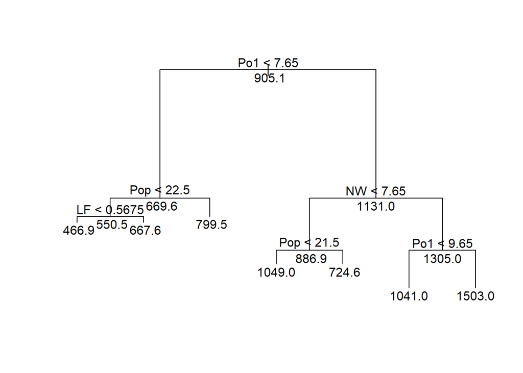

```r
crime_tree <- tree(
  Crime ~ .,
  data = uscrime
)
plot(crime_tree)
text(crime_tree, all = TRUE, pretty = 0)
```

Now that we understand how to interpret a single tree, let’s grow a full forest.

```r
set.seed(1234) # Allows you to replicate results for 'Random' Forest
crime_rf <- randomForest(
  Crime ~ .,          # Formula
  data = uscrime,     # Source data set
  ntree = 250,        # How many trees we grow
  nodesize = 5,       # How tall we allow the tree to grow
  replace = TRUE,     # If we allow the sampling of the same data point for a single tree
  importance = TRUE,  # Performance details
  localImp = TRUE     # Performance details
)
```

In our model we created 250 different trees. These trees were all brought back together in an ensemble. A side effect of the ensemble is that we lose some interpretability of the model. We cannot point to a particular tree and a particular branch to say “this is why the prediction provided value *x*.”

There model does return a few stats to help interpret its peformance.

```r
# Mean-Squared Error of the model
crime_rf$mse
```

```
##   [1] 258031.36 194238.28 159187.93 168545.97 154768.90 154478.63 161942.92
##   [8] 152659.33 144036.39 138999.42 132917.07 114446.68 104113.28 109806.32
##  [15] 107309.63 113723.47 107475.15 101992.42  98371.50  95514.04  91681.10
##  [22]  92475.00  90461.56  91150.39  91954.69  93499.23  91579.13  90917.08
##  [29]  95049.59  93907.93  91499.03  91855.86  90140.31  91273.06  91545.52
##  [36]  92462.48  91345.47  91538.30  89593.48  91152.13  89036.61  89174.79
##  [43]  87986.06  88320.49  87626.77  88597.57  88345.11  88745.54  88403.34
##  [50]  88432.68  89600.52  90422.87  90234.53  89227.55  87581.89  87676.64
##  [57]  87892.16  85943.67  83870.07  84235.38  84008.09  84617.11  84374.25
##  [64]  84930.16  84522.98  84858.72  85043.43  86206.41  85675.55  85347.84
##  [71]  85197.64  84320.87  83516.81  83274.08  82582.43  81160.48  80648.38
##  [78]  80365.12  79515.59  79508.84  79516.43  79092.09  79694.97  78776.18
##  [85]  78574.83  78481.09  77759.61  77778.63  77335.12  77321.92  78237.66
##  [92]  78828.60  79126.25  79528.14  80029.85  79113.68  79277.00  78875.37
##  [99]  79491.31  78881.16  78566.54  78251.47  78711.67  78555.05  78536.98
```

[output cut: 21 more lines]

```r
# R Squared score - % of variance explained by model
crime_rf$rsq
```

```
##   [1] -0.76247657 -0.32673961 -0.08732907 -0.15124892 -0.05714502
##   [6] -0.05516235 -0.10614695 -0.04273566  0.01616312  0.05056804
##  [11]  0.09211337  0.21827491  0.28885693  0.24997076  0.26702430
##  [16]  0.22321478  0.26589372  0.30334337  0.32807601  0.34759382
##  [21]  0.37377459  0.36835189  0.38210466  0.37739962  0.37190588
##  [26]  0.36135589  0.37447112  0.37899321  0.35076622  0.35856432
##  [31]  0.37501823  0.37258088  0.38429892  0.37656170  0.37470064
##  [36]  0.36843743  0.37606711  0.37474999  0.38803400  0.37738769
##  [41]  0.39183773  0.39089385  0.39901348  0.39672913  0.40146760
##  [46]  0.39483659  0.39656096  0.39382589  0.39616326  0.39596285
##  [51]  0.38798593  0.38236888  0.38365536  0.39053349  0.40177412
##  [56]  0.40112694  0.39965488  0.41296399  0.42712762  0.42463240
##  [61]  0.42618487  0.42202501  0.42368384  0.41988670  0.42266792
##  [66]  0.42037470  0.41911304  0.41116934  0.41479537  0.41703380
##  [71]  0.41805973  0.42404845  0.42954057  0.43119855  0.43592283
```

[output cut: 35 more lines]

```r
crime_rf$importance
```

```
##           %IncMSE IncNodePurity
## M       5153.3803     216561.21
## So       860.1521      21739.96
## Ed      5168.6408     202858.09
## Po1    38781.8025    1201041.73
## Po2    27545.4174    1127990.26
## LF      2837.6166     332583.84
## M.F     -782.7835     236231.68
## Pop     -203.0019     360270.53
## NW     17816.1756     561507.53
## U1       147.3488     114366.08
## U2      1610.1519     155364.24
## Wealth  7377.2022     647937.07
## Ineq     992.6367     245142.48
## Prob   15884.0223     736907.16
## Time    2573.0537     225581.90
```

```r
# Display the standard errors
crime_rf$importanceSD
```

```
##         M        So        Ed       Po1       Po2        LF       M.F
## 1403.0765  369.3548 1789.6333 4232.7521 3990.6604 1769.7942 1052.2382
##       Pop        NW        U1        U2    Wealth      Ineq      Prob
## 1050.4038 2644.3263  790.1807 1188.9149 2197.6812 1302.2722 2577.8764
##      Time
##  994.2672
```

```r
crime_rf$localImportance
```

```
##                 1          2          3          4          5           6
## M       7742.2388  46693.252  -750.2602  48124.329   2288.513   38432.848
## So      1455.0295      0.000  -174.2442      0.000  -4187.070       0.000
## Ed      -270.9793 -15802.645 24286.6876  29275.147   6357.839   19533.721
## Po1    22008.3731  81401.052 91967.0408 182468.542  14195.968  -44780.383
## Po2    40593.4459  73083.756 47687.5604 221740.877  16466.967 -101162.344
## LF     -5653.4580  26906.932  8037.6940  51898.896 -12868.133  -27263.838
## M.F     -312.3447   4202.383  3516.7922   4544.044  -9602.363   31843.245
## Pop     7848.1030  -5481.710  -340.8566  -5699.911   5199.055   23036.625
## NW      4101.4913 104782.446 -9252.8833  75144.795 -41443.362   48268.961
## U1     -2758.2136  -1865.962   335.7740   4385.044  -2752.689    9897.339
## U2      1695.9151  -7376.983  3094.3605  56043.314 -30669.664   -2464.632
## Wealth  3910.4329  -7100.948 34836.6627  64389.956   7151.926 -297154.372
## Ineq    2557.6924  20294.985 -4766.5907 -27345.710 -12016.891   35651.347
## Prob   35665.0128  56474.728 51832.3777 101380.694   4512.546   -7618.905
## Time    7064.5286  18431.708   913.6281  29714.242  -5083.464    3360.976
##                  7          8          9          10          11
## M       -5267.8222 -21143.360  9860.5940   -232.3325 -86304.9504
## So        927.8634   6536.972  2336.9465    929.7591   -888.5854
## Ed       4583.3244   4203.164  9914.7068  11815.9430  -6264.1235
## Po1     23905.0427 103159.487 19072.1524  58704.8798  54134.5546
## Po2     15097.2917  73814.355 15070.5681  42187.9425  73723.3150
## LF        240.3801  -4352.166  6400.8565 -12249.5137  33080.5234
## M.F      4044.7569 -11579.234  2140.1109 -22367.6753 -12795.0453
## Pop     -7714.1448 -18637.762  7647.6502   4786.9659 -13090.9153
## NW       9381.2099  40093.007 14969.6792   5693.8390 101767.8607
## U1       -961.8293 -30682.880  3324.3371   2204.6621  -2729.3207
## U2       5190.8941  14963.637  -884.7745  -8378.1737  -2958.9686
## Wealth  17732.6653  -1817.735 26840.9501  -4449.3839  24313.1607
## Ineq     7873.8110   7311.096  2903.4773    809.6038 -24295.5752
## Prob   -14433.3039   2305.484 24562.3219  33420.5951  82223.2673
## Time    -2014.3660  17993.993  1242.3196    800.2897  14953.5000
##                12         13         14         15          16         17
## M       2732.4781  1518.4081 -2998.3673  3542.5796 -2502.84580   867.6273
## So     -2885.0392  5904.4286   569.8500  3568.3823  2879.69962    -2.0022
## Ed       134.3876   116.3615  -664.0712  1878.6140 16433.90398 -1691.1068
## Po1    46615.2368 34956.6186 69321.3305 35938.2507 22765.86183 65103.2542
## Po2    28298.7678 89996.3490 33951.5433 11132.1567 15686.65281 46605.0839
## LF      4205.4604 -1732.4372  1327.7715   703.8502  5347.16377  4639.2460
## M.F    -5547.8188 11496.3526  2083.2600 -1933.2350  7505.09439  1173.0932
```

[output cut: 89 more lines]

```
## M        6122.3094  41236.789   6059.06622
## So      -4653.2398      0.000     31.70875
## Ed       -555.7840   5855.924  -1183.92887
## Po1     68154.0729 -92380.029  22322.54227
## Po2    115369.1320 -48562.887   4082.02691
## LF       1777.6305 -28072.583 -14158.60934
## M.F      2659.7069  -3221.895 -16273.17594
## Pop     11492.4579   3147.383 -58441.15750
## NW      -4090.1116  81171.718  35193.56867
## U1       1531.7592 -24029.040  13315.94906
## U2       -799.0984  36598.227   1704.86820
## Wealth   7493.3788  41448.129   4829.41878
## Ineq     4112.2123 -19828.155  11547.41348
## Prob    17088.2235  67474.268  14448.15468
## Time     1845.5612  27272.614  16228.16618
```

However, I may select the Tree Regression to brief to leadership. The decision tree structure is easy for non-analytical teammates to follow. It also becomes actionable. The team can strategically target a node on the tree.

## 10.2

**Describe a situation or problem from your job, everyday life, current events, etc., for which a logistic regression model would be appropriate. List some (up to 5) predictors that you might use.**

There is a site called [Numerai](https://numer.ai) that blends the ideas of high frequency traders and Kaggle data competitions. Each week a new round opens up and thousands of data scientists/quants train models to submit. The source data is transformed in such a way that the modeler cannot know what signals or stocks they are modeling to trade.

Numerai gets lots of models that they can create an ensemable out of to buy and trade these stocks. Then you, as the modeler, get a kick back for how well your model performs and the uniqueness of the model.

Logistic regression works well in this scenario because they want a binary decision - Buy or Sell. However, they ask that you provide the results in a confidence percentage instead. This way they can set their own threshold for when to trust your model.

Due to Numerai cleaning, prepping, and obscuring the source the feature names are not so exciting. The data set includes predictors like:

- Feature_1
- Feature_2
- …
- Feature_50

Either way, it’s a fun clean place to practice your modelling skills and possibly earn some change on the side!

## 10.3

1. **Using the GermanCredit data set `germancredit.txt` from …, use logisitc regression to find a good predictive model for whether credit applicants are good credit risks or not. Show your model (factors used and their coefficients), the software output, and the quality of fit. You can use the `glm` function in R.**
2. **Because the model gives a result between 0 and 1, it requires a threshold probablity to separate between “good” and “bad” answers. In this data set, they estimate that incorrectly identifying a bad customer as good, is 5 times worse than incorrectly classifying a good customer as bad. Determine a good threshold probability based on your model.**

```r
gercredit <- read.table("data/germancredit.txt")
glimpse(gercredit)
```

```
## Observations: 1,000
## Variables: 21
## $ V1  <fct> A11, A12, A14, A11, A11, A14, A14, A12, A14, A12, A12, A11...
## $ V2  <int> 6, 48, 12, 42, 24, 36, 24, 36, 12, 30, 12, 48, 12, 24, 15,...
## $ V3  <fct> A34, A32, A34, A32, A33, A32, A32, A32, A32, A34, A32, A32...
## $ V4  <fct> A43, A43, A46, A42, A40, A46, A42, A41, A43, A40, A40, A49...
## $ V5  <int> 1169, 5951, 2096, 7882, 4870, 9055, 2835, 6948, 3059, 5234...
## $ V6  <fct> A65, A61, A61, A61, A61, A65, A63, A61, A64, A61, A61, A61...
## $ V7  <fct> A75, A73, A74, A74, A73, A73, A75, A73, A74, A71, A72, A72...
## $ V8  <int> 4, 2, 2, 2, 3, 2, 3, 2, 2, 4, 3, 3, 1, 4, 2, 4, 4, 2, 4, 3...
## $ V9  <fct> A93, A92, A93, A93, A93, A93, A93, A93, A91, A94, A92, A92...
## $ V10 <fct> A101, A101, A101, A103, A101, A101, A101, A101, A101, A101...
## $ V11 <int> 4, 2, 3, 4, 4, 4, 4, 2, 4, 2, 1, 4, 1, 4, 4, 2, 4, 3, 2, 2...
## $ V12 <fct> A121, A121, A121, A122, A124, A124, A122, A123, A121, A123...
## $ V13 <int> 67, 22, 49, 45, 53, 35, 53, 35, 61, 28, 25, 24, 22, 60, 28...
## $ V14 <fct> A143, A143, A143, A143, A143, A143, A143, A143, A143, A143...
## $ V15 <fct> A152, A152, A152, A153, A153, A153, A152, A151, A152, A152...
## $ V16 <int> 2, 1, 1, 1, 2, 1, 1, 1, 1, 2, 1, 1, 1, 2, 1, 1, 2, 3, 1, 1...
## $ V17 <fct> A173, A173, A172, A173, A173, A172, A173, A174, A172, A174...
## $ V18 <int> 1, 1, 2, 2, 2, 2, 1, 1, 1, 1, 1, 1, 1, 1, 1, 1, 1, 1, 1, 2...
## $ V19 <fct> A192, A191, A191, A191, A191, A192, A191, A192, A191, A191...
## $ V20 <fct> A201, A201, A201, A201, A201, A201, A201, A201, A201, A201...
## $ V21 <int> 1, 2, 1, 1, 2, 1, 1, 1, 1, 2, 2, 2, 1, 2, 1, 2, 1, 1, 2, 1...
```

`V21` is our target variable, but the logisitic regression models need the target variable to be 0 or 1, not 1 or 2.

In the dataset documentation 1 is considered a good loan and 2 is considered a bad loan. Let’s recode 2 to 0 for our model.

```r
gercredit <- mutate(gercredit, V21 = ifelse(V21 == 2, 0, 1))
```

```r
credit_glm_all <- glm(
  V21 ~ .,
  family = binomial(link = "logit"),
  data = gercredit
)
summary(credit_glm_all)
```

```
##
## Call:
## glm(formula = V21 ~ ., family = binomial(link = "logit"), data = gercredit)
##
## Deviance Residuals:
##     Min       1Q   Median       3Q      Max
## -2.6116  -0.7095   0.3752   0.6994   2.3410
##
## Coefficients:
##               Estimate Std. Error z value Pr(>|z|)
## (Intercept) -4.005e-01  1.084e+00  -0.369 0.711869
## V1A12        3.749e-01  2.179e-01   1.720 0.085400 .
## V1A13        9.657e-01  3.692e-01   2.616 0.008905 **
## V1A14        1.712e+00  2.322e-01   7.373 1.66e-13 ***
## V2          -2.786e-02  9.296e-03  -2.997 0.002724 **
## V3A31       -1.434e-01  5.489e-01  -0.261 0.793921
## V3A32        5.861e-01  4.305e-01   1.362 0.173348
## V3A33        8.532e-01  4.717e-01   1.809 0.070470 .
## V3A34        1.436e+00  4.399e-01   3.264 0.001099 **
## V4A41        1.666e+00  3.743e-01   4.452 8.51e-06 ***
## V4A410       1.489e+00  7.764e-01   1.918 0.055163 .
## V4A42        7.916e-01  2.610e-01   3.033 0.002421 **
## V4A43        8.916e-01  2.471e-01   3.609 0.000308 ***
## V4A44        5.228e-01  7.623e-01   0.686 0.492831
## V4A45        2.164e-01  5.500e-01   0.393 0.694000
## V4A46       -3.628e-02  3.965e-01  -0.092 0.927082
## V4A48        2.059e+00  1.212e+00   1.699 0.089297 .
## V4A49        7.401e-01  3.339e-01   2.216 0.026668 *
## V5          -1.283e-04  4.444e-05  -2.887 0.003894 **
## V6A62        3.577e-01  2.861e-01   1.250 0.211130
## V6A63        3.761e-01  4.011e-01   0.938 0.348476
## V6A64        1.339e+00  5.249e-01   2.551 0.010729 *
## V6A65        9.467e-01  2.625e-01   3.607 0.000310 ***
## V7A72        6.691e-02  4.270e-01   0.157 0.875475
## V7A73        1.828e-01  4.105e-01   0.445 0.656049
## V7A74        8.310e-01  4.455e-01   1.866 0.062110 .
## V7A75        2.766e-01  4.134e-01   0.669 0.503410
## V8          -3.301e-01  8.828e-02  -3.739 0.000185 ***
## V9A92        2.755e-01  3.865e-01   0.713 0.476040
## V9A93        8.161e-01  3.799e-01   2.148 0.031718 *
```

[output cut: 14 more lines]

```
## V17A173     -5.547e-01  6.549e-01  -0.847 0.397015
## V17A174     -4.795e-01  6.623e-01  -0.724 0.469086
## V18         -2.647e-01  2.492e-01  -1.062 0.288249
## V19A192      3.000e-01  2.013e-01   1.491 0.136060
## V20A202      1.392e+00  6.258e-01   2.225 0.026095 *
## ---
## Signif. codes:  0 '***' 0.001 '**' 0.01 '*' 0.05 '.' 0.1 ' ' 1
##
## (Dispersion parameter for binomial family taken to be 1)
##
##     Null deviance: 1221.73  on 999  degrees of freedom
## Residual deviance:  895.82  on 951  degrees of freedom
## AIC: 993.82
##
## Number of Fisher Scoring iterations: 5
```

In the summary of the model, we can see the coefficients used with all the features, their standard error, and the significance that they contribute to the model.

Looking closely at the features you may notice that the categorical features have been expanded into each of their options. `V1` became `V1A12`, `V1A13`, and `V1A14`. Whereas `V2` remained `V2` because it is a numerical feature.

This idea of breaking a categorical feature into one column for each category and labeling it as a binary *yes* or *no* is known as **one-hot encoding**.

The summary also provides the AIC score, which is a measure of the models complexity. In this case, the AIC is high, which is to be expected since we threw the EVERY feature at it.

Now that we have our model trained, we can feed the data through it to get predictions.

```r
credit_p_all <- predict(credit_glm_all, gercredit, "response")
head(credit_p_all)
```

```
##         1         2         3         4         5         6
## 0.9647683 0.3677376 0.9719376 0.7481979 0.2479989 0.7376644
```

The prediction returns the model’s confidence in a positive classification. With these percentages we can set a threshold for when we will accept a positive classification.

Since false positives *(Type 1 Error)* are 5x as costly as a false negative *(Type 2 Error)*, we will want to set a higher threshold.

A confusion matrix is a good tool to check how many type 1 vs. type 2 errors you are making.

```r
# You must be 70% sure this is a good idea before we will accept it!
threshold <- 0.7

# This was bit of an odd step. I was not expecting to have to convert these to a factor.
# I also needed to install the `e1071` package before the confusion matrix would work.
pred_factor <- factor(as.numeric(credit_p_all > threshold))
target_factor <- factor(gercredit$V21)

confusionMatrix(
  data = pred_factor,
  reference = target_factor
)
```

```
## Confusion Matrix and Statistics
##
##           Reference
## Prediction   0   1
##          0 232 176
##          1  68 524
##
##                Accuracy : 0.756
##                  95% CI : (0.7281, 0.7823)
##     No Information Rate : 0.7
##     P-Value [Acc > NIR] : 4.795e-05
##
##                   Kappa : 0.4732
##
##  Mcnemar's Test P-Value : 7.386e-12
##
##             Sensitivity : 0.7733
##             Specificity : 0.7486
##          Pos Pred Value : 0.5686
##          Neg Pred Value : 0.8851
##              Prevalence : 0.3000
##          Detection Rate : 0.2320
##    Detection Prevalence : 0.4080
##       Balanced Accuracy : 0.7610
##
##        'Positive' Class : 0
##
```

The confusion matrix just gives us a snapshot of setting a single threshold. What if we want to look at all the possible thresholds and their true positive / false positive tradeoff?

Well for that, we can use a Reciever Operating Characteristic or ROC curve.

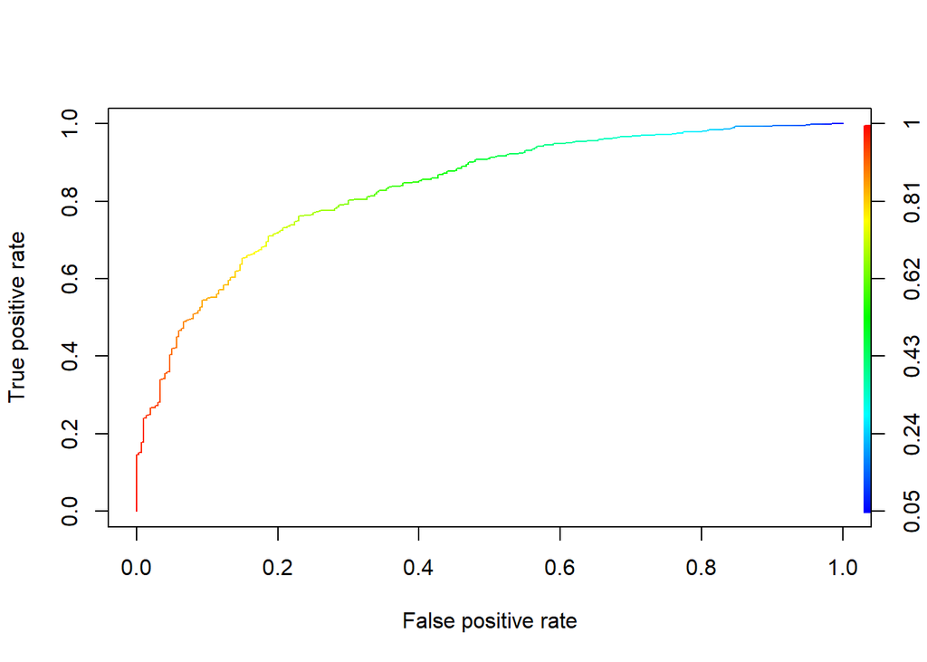

```r
credit_pred_all <- prediction(credit_p_all, gercredit$V21)
credit_perf_all <- performance(credit_pred_all, "tpr", "fpr")
plot(credit_perf_all, colorize = TRUE)
```

I found the color very helpful on this plot for highlighting the ideal threshold.

At the extremes, a threshold of 1, meaning the model needs to be **100%** certain that this is really a good idea, we get 0 positives.  
A threshold of 0, meaning we let every data point come through as a positive “good idea” we are right about 100% of the true positives, but we also have 100% of the true negatives.

The sweet spot for our case looks to be around the orangish-yellow area. ~.8 threshold. This will let us capture 60% of the proverbial good eggs and only let ~15% of bad eggs through.

After talking with management, they may still want to increase the threshold. You will be turning away a lot of good customers, but you won’t have as much risk with a bad one.

*I could go on and refine the model to get more Area Under the Curve (AUC), but I believe I’ve demonstrated my ability to refine a model in the questions above and that I have met the requirements for this question. The same tactics to optimize a regression model apply to a classification model.*